# fpp2_3

yinshu zhang

September 1, 2019

# simple forecasting methods

### Average

mean of all data

### Naive

last obvervation

### seasonal naive

last obvervation of same season

### drife method

naive with increase/decrease over time. the drift is average change in data,

> This is equivalent to drawing a line between the first and last observations

# transformation

### Box-Cox transformation:

$w_t = log(y_t)$ if $\lambda =0$ log is e based, $w_t=(y_t^\lambda-1)/\lambda$ is $\lambda \ne 0$

> A good value of λ is one which makes the size of the seasonal variation about the same across the whole series, as that makes the forecasting model simpler.

```r
lambda <- BoxCox.lambda(elec)
lambda
```

```
## [1] 0.2654076
```

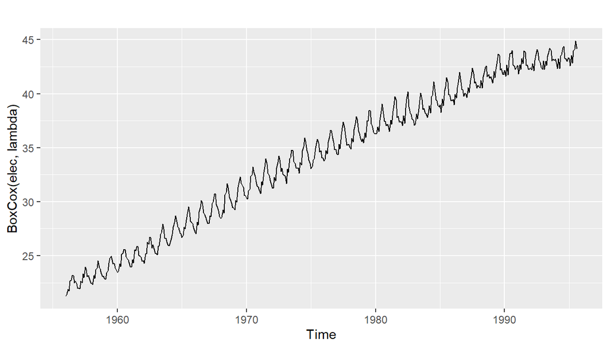

```r
autoplot(BoxCox(elec,lambda))
```

### back transform and bias adjustments

when forecast the transformed data, you need to reverse (back-transform) to original scale. reversed box-cox is

$y_t=exp(w_t)$ if $\lambda=0$, otherwise $(\lambda w_t +1)^{1/\lambda}$

simple back-transform give median, if you need mean of orignal scale, use biad-adjusted.

> Bias adjustment is not done by default in the forecast package. if you want your forecast to be means rather than medians, use the argument biasadj=TRUE when you select your Box-Cox transformation parameter.

# residual diagnostics

### fitted values

value forecasted with previous time series is called fitted value. $\hat{y}_{t|t-1}$ is forecast of $y_t$ base on observations of $y_1$,…,$y_{t-1}$, shorthanded $\hat{y}_t$. fitted values always involve one-step forecasts. Fitted values often are not true forecast because parameters involved in the forecasting method are estimated using all available observations.

### Residuals

Residuals is what left over after fitting a model. $e_t=y_t-\hat{y}_t$. Residual is useful checking if model captured adequate information of time series. a good forecasting model should have residuels with 1, uncorrelated, 2, have zero mean. > Any forecasting method that does not satisfy these properties can be improved. However, that does not mean that forecasting methods that satisfy these properties cannot be improved. It is possible to have several different forecasting methods for the same data set, all of which satisfy these properties. Checking these properties is important in order to see whether a method is using all of the available information, but it is not a good way to select a forecasting method.

In addition, useful but no necessary for residuals also should 1, have constant variance, 2, normally distrubted. sometime apply box-cox transformation can help.

# Ljung-Box test, Box-Pierce test

> A test for a group of autocorrelations is called a portmanteau test, from a French word describing a suitcase containing a number of items.

Box-Pierce test: $r_l$ is autocorrelation for lag k, T is number of observations, and h is max lag then $Q=T\sum_{k=1}^h r^2_k$

Ljung-Box test is related but more accurate test $Q*=T(T+2)\sum_{k=1}^h(T-k)^{-1}r_k^2$

Large Q suggest autocorreation do not come from a white noise. If autocorrelation come from noise, then both Q and Q* would have $\chi^2$ distribution with (h-K) degree of freedom, where K is number of parameters in the model.

example of naive model has no parameter, so K=0

```r
res <- residuals(naive(goog200))
Box.test(res, lag=10, fitdf=0)
```

```
##
##  Box-Pierce test
##
## data:  res
## X-squared = 10.611, df = 10, p-value = 0.3886
```

```r
Box.test(res,lag=10, fitdf=0, type="Lj")
```

```
##
##  Box-Ljung test
##
## data:  res
## X-squared = 11.031, df = 10, p-value = 0.3551
```

bot Q and Q* are not significant(ie p-value is large), thus residual are not distringuishable from noise.

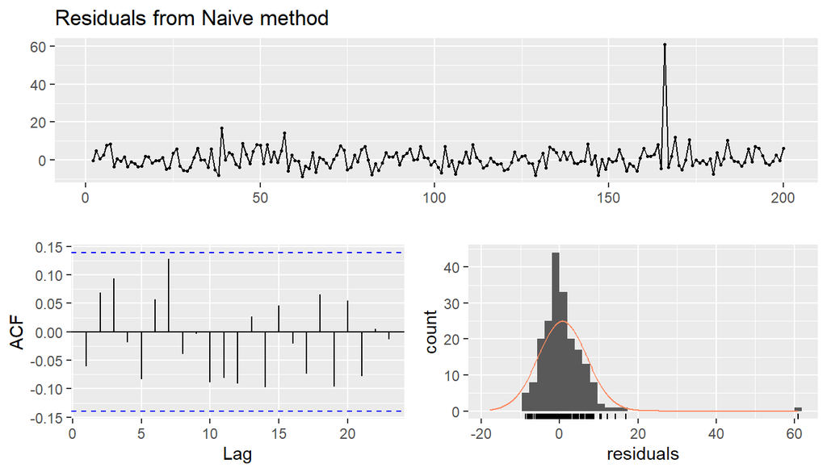

```
##
##  Ljung-Box test
##
## data:  Residuals from Naive method
## Q* = 11.031, df = 10, p-value = 0.3551
##
## Model df: 0.   Total lags used: 10
```

```r
checkresiduals(naive(goog200))
```

# forecast accuracy

### forecast error

forecast error is unpredictable part. note the forecast error isnot residuals. residules are calculated on training set, forecast error are calculated on test set. Second, residual are one-step forecasts, forecast error can involve multi-step forecasts.

### scal-dependent MAE and RMES

Mean absolute error, MAE = mean($|e_t|$) Root mean squared error, RMSE = $\sqrt{mean(e_t^2)}$

### percentage errors

Mean absolute percentage error: MAPE = $mean(|p_t|)$, $p_t = 100e_t/y_t$.

MAPE is unit free. but if $y_t$ is zero ro very close to zero, for any t, MAPE would be undefined or infinite. This problem is because if $y_t$ assumed being zero is meaningful. Also MAPE penalize negative errors more than positive errors.

sMAPE or “symmetric” MAPE is proposed, sMAPE=$mean(200|y_t-\hat{y_t}/(y_t+\hat{y_t}))$. Hoever if $y_t$ is close to zero, $\hat{y_t}$ is also likely to close tozero, so this measure still involve divided by zero problem, also sMAPE can be negative, so it’s no t a real “absolute percentage error”. some recommend not to use sMAPE but still it’s widely used.

### Scaled error

scaled error is proposed by author (2006) as an alternative using percentage error. it scaling error ase on traianing MAE from simple forecast method.

MASE = $mean(|q_j|)$, $q_j$ is simple forecast value, can be seasonal or non-seasonal.

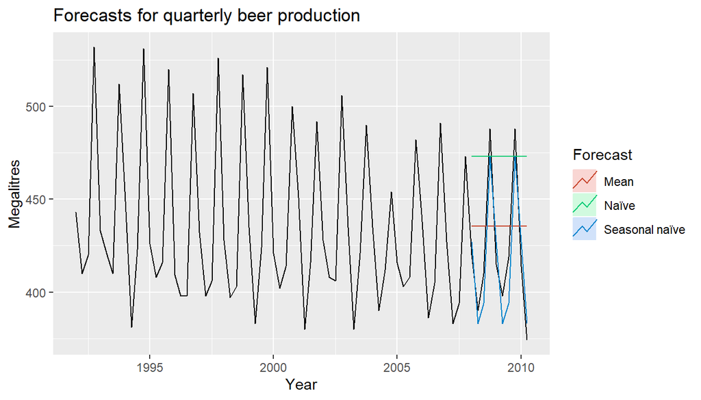

```r
beer2 <- window(ausbeer,start=1992,end=c(2007,4))
beerfit1 <- meanf(beer2,h=10)
beerfit2 <- rwf(beer2,h=10)
beerfit3 <- snaive(beer2,h=10)
autoplot(window(ausbeer, start=1992)) +
  autolayer(beerfit1, series="Mean", PI=FALSE) +
  autolayer(beerfit2, series="Naïve", PI=FALSE) +
  autolayer(beerfit3, series="Seasonal naïve", PI=FALSE) +
  xlab("Year") + ylab("Megalitres") +
  ggtitle("Forecasts for quarterly beer production") +
  guides(colour=guide_legend(title="Forecast"))
```

```r
# test set
beer3 <- window(ausbeer, start=2008)
accuracy(beerfit1, beer3)
```

```
##                   ME     RMSE      MAE        MPE     MAPE     MASE
## Training set   0.000 43.62858 35.23438 -0.9365102 7.886776 2.463942
## Test set     -13.775 38.44724 34.82500 -3.9698659 8.283390 2.435315
##                     ACF1 Theil's U
## Training set -0.10915105        NA
## Test set     -0.06905715  0.801254
```

```r
accuracy(beerfit2, beer3)
```

```
##                       ME     RMSE      MAE         MPE     MAPE     MASE
## Training set   0.4761905 65.31511 54.73016  -0.9162496 12.16415 3.827284
## Test set     -51.4000000 62.69290 57.40000 -12.9549160 14.18442 4.013986
##                     ACF1 Theil's U
## Training set -0.24098292        NA
## Test set     -0.06905715  1.254009
```

```r
accuracy(beerfit3, beer3)
```

```
##                     ME     RMSE  MAE        MPE     MAPE      MASE
## Training set -2.133333 16.78193 14.3 -0.5537713 3.313685 1.0000000
## Test set      5.200000 14.31084 13.4  1.1475536 3.168503 0.9370629
##                    ACF1 Theil's U
## Training set -0.2876333        NA
## Test set      0.1318407  0.298728
```

Season vaive method is best choice

below is a non-seasonal example

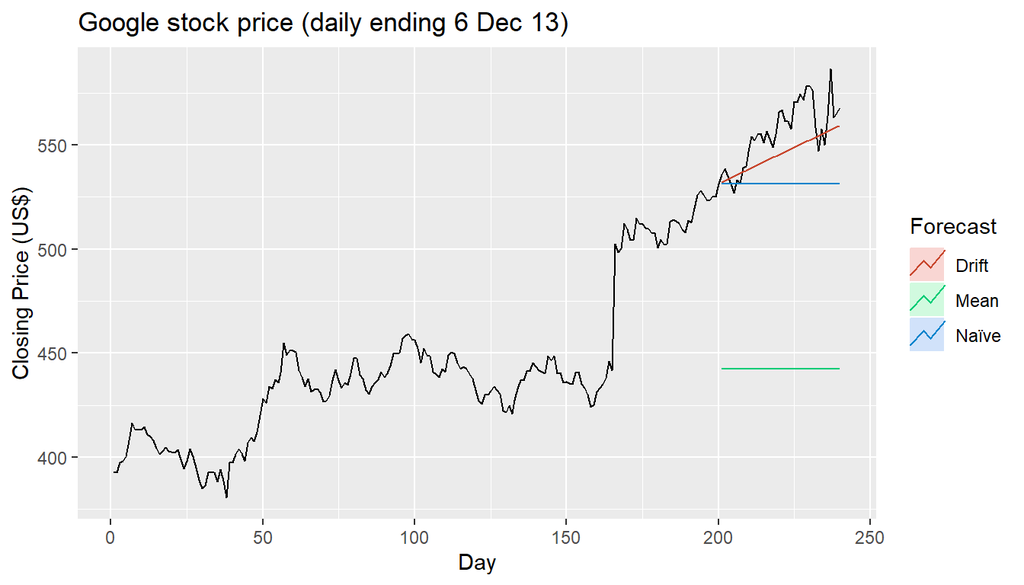

```r
googfc1 <- meanf(goog200, h=40)
googfc2 <- rwf(goog200, h=40)
googfc3 <- rwf(goog200, drift=TRUE, h=40)
autoplot(subset(goog, end = 240)) +
  autolayer(googfc1, PI=FALSE, series="Mean") +
  autolayer(googfc2, PI=FALSE, series="Naïve") +
  autolayer(googfc3, PI=FALSE, series="Drift") +
  xlab("Day") + ylab("Closing Price (US$)") +
  ggtitle("Google stock price (daily ending 6 Dec 13)") +
  guides(colour=guide_legend(title="Forecast"))
```

```r
# test
googtest <- window(goog, start=201, end=240)
accuracy(googfc1, googtest)
```

```
##                         ME      RMSE       MAE        MPE     MAPE
## Training set -4.296286e-15  36.91961  26.86941 -0.6596884  5.95376
## Test set      1.132697e+02 114.21375 113.26971 20.3222979 20.32230
##                   MASE      ACF1 Theil's U
## Training set  7.182995 0.9668981        NA
## Test set     30.280376 0.8104340  13.92142
```

```r
accuracy(googfc2, googtest)
```

```
##                      ME      RMSE       MAE       MPE      MAPE     MASE
## Training set  0.6967249  6.208148  3.740697 0.1426616 0.8437137 1.000000
## Test set     24.3677328 28.434837 24.593517 4.3171356 4.3599811 6.574582
##                     ACF1 Theil's U
## Training set -0.06038617        NA
## Test set      0.81043397  3.451903
```

```r
accuracy(googfc3, googtest)
```

```
##                         ME      RMSE       MAE         MPE      MAPE
## Training set -5.998536e-15  6.168928  3.824406 -0.01570676 0.8630093
## Test set      1.008487e+01 14.077291 11.667241  1.77566103 2.0700918
##                  MASE        ACF1 Theil's U
## Training set 1.022378 -0.06038617        NA
## Test set     3.119002  0.64732736  1.709275
```

Here the best method is drift.

### cross-validation, tsCV

“evaluation on a rolling forecasting origin”, the forecast accuracy is computed by average over test set that is rolling forward in time, either one-step or multi-step head of training set. see [illustration](https://otexts.com/fpp2/accuracy.html)

> `tsCV` computes the forecast errors obtained by applying forecastfunction to subsets of the time series y using a rolling forecast origin.

```r
e <- tsCV(goog200, rwf, drift=TRUE, h=1)
# MSE
sqrt(mean(e^2, na.rm=TRUE))
```

```
## [1] 6.233245
```

```r
# RMSE
sqrt(mean(residuals(rwf(goog200, drift=TRUE))^2, na.rm=TRUE))
```

```
## [1] 6.168928
```

smaller RMSE is better

# Apendix

### chi square test

is change of variable due to chance along? df = number of outcome -1. right tail test, if test value less than critical vaule, failed to reject H0, if more than critical value then reject H0. H0 is that the chagne is due to chance, (true randomness?)